# CO2 AF calcs

17/02/25

CO2 with ADMs from VM 07/01/25

Working from N2O notebook, https://phockett.github.io/ePSdata/N2O-preliminary/N2O_AF_basicPlots_120624.html

Updates:

- Updated ADM class for text file case.
  - Ran with `wignerDpoly` norm... get results, but quite a lot of singularities/large values, suggesting renorm issue? Tested thres=1e-5, 1e-6 and not much change.
  - Ran with `wignerDlinear` norm... looks a bit better, suggesting renorm issue? Tested thres=1e-6 and not much change.
  - Ran with `sph` norm... very small beta params on average, B00 in 6 to 8 ish range, but get smoother results and no singularities.
  - Hmmm, go with `sph` for now, although need to confirm values - maybe still have issues here...

12/06/24

- Rerun for trange=[17,23]
- Use updated HV plotting routines.

22/03/24

Alignment frame calcs preliminary:

- Load and plot alignment data (ADMs) for all temperatures.
- Compute AF results for given temp (with t downsampling), note default case assumes linear pol, $z$-axis alignment.
- Plot XS and betas, interactive heatmaps and line plots.

**Note all plots are interactive, mouse-over for data points, and use toolbars for zoom/selection, and widgets for browsing data types (where applicable).**

For general methods: https://epsproc.readthedocs.io/en/dev/demos/ePSproc_class_demo_161020.html

```python
# Quick hack to override default HTML template
# NOT required in some JLab versions.
# https://stackoverflow.com/a/63777508
# https://stackoverflow.com/questions/21971449/how-do-i-increase-the-cell-width-of-the-jupyter-ipython-notebook-in-my-browser
from IPython.core.display import display, HTML
display(HTML("<style>.container { width:100% !important; }</style>"))
```

```python
%load_ext autoreload
%autoreload 2
```

## Load alignment data

Now with ADM class.

```python
from epsproc.classes.alignment import ADM
from pathlib import Path

# dataPath = Path('~/ePS/N2O/alignment/Wigner D polyatomic normalized')
# dataPath = Path('~/jake-home/ePS/N2O/alignment/Wigner D polyatomic normalized')
dataPath = Path('~/jake-home/projects-share/woodhouse_minns_collabs_2023/co2_eli_2024/CO2_ADMs_070125')

ADMtype = '.txt'

# - Ran with `wignerDpoly` norm... get results, but quite a lot of singularities/large values, suggesting renorm issue? Tested thres=1e-5, 1e-6 and not much change.
# - Ran with `wignerDlinear` norm... looks better, suggesting renorm issue? Tested thres=1e-6 and not much change.
# - Ran with 'sph' norm... very small beta params on average, B00 in 6 to 8 ish range, but get smoother results and no singularities.
# Hmmm, go with sph for now, although need to confirm values - maybe still have issues here...
normType='sph'

ADMin = ADM(fileBase=dataPath.expanduser(), ext = ADMtype)

ADMin.loadData(keyType='fileName', normType=normType, addQ = True)
# ADMin.loadData(keyType='T')
# ADMin.loadData(keyType='setADMsT')
# ADMin.loadData(keyType='setADMsT', addS=False, addPop=False)
```

```
OMP: Info #276: omp_set_nested routine deprecated, please use omp_set_max_active_levels instead.
```

```
* sparse not found, sparse matrix forms not available.
* natsort not found, some sorting functions not available.
```

```
* Setting plotter defaults with epsproc.basicPlotters.setPlotters(). Run directly to modify, or change options in local env.
```

```
* Set Holoviews with bokeh.
* pyevtk not found, VTK export not available.
Scanning /home/jovyan/jake-home/projects-share/woodhouse_minns_collabs_2023/co2_eli_2024/CO2_ADMs_070125 for ePS jobs.
Found ePS output files in subdirs: [PosixPath('/home/jovyan/jake-home/projects-share/woodhouse_minns_collabs_2023/co2_eli_2024/CO2_ADMs_070125/.ipynb_checkpoints')]
Found ePS output files in root dir /home/jovyan/jake-home/projects-share/woodhouse_minns_collabs_2023/co2_eli_2024/CO2_ADMs_070125.

*** Scanning dir
/home/jovyan/jake-home/projects-share/woodhouse_minns_collabs_2023/co2_eli_2024/CO2_ADMs_070125
Found 5 .txt file(s)

Set self.norm from self.norms['sph'].
Found t-index /home/jovyan/jake-home/projects-share/woodhouse_minns_collabs_2023/co2_eli_2024/time.txt
*** Attempting to sort text files assuming one file per ADM...
Files from self.fileDict read OK, outputs: self.dataDict and self.data.
```

```python
# ADMin.data['CO2_ADMs_070125']['ADM']
```

```python
# import epsproc as ep

# ep.setADMs

ADMin.plot(width=1000)
# ADMin.plot(xlim=(30,50), width=800)  # Auto-stack plus pass args & zoom in on specific region (note slider will reset region with interactive zoom)
```

## Load matrix elements

```python
# Plotters
# from epsproc.plot import hvPlotters

# Multijob class dev code
from epsproc.classes.multiJob import ePSmultiJob

# import warnings
# # warnings.filterwarnings('once')   # Skip repeated numpy deprecation warnings in current build (xr15 env)
# warnings.filterwarnings('ignore')   # Skip repeated numpy deprecation warnings in current build (xr15 env)
```

```python
# # Scan for subdirs, based on existing routine in getFiles()

# fileBase = Path('/home/paul/ePS/OCS/OCS_survey')  # Data dir on Stimpy

# fileBase = Path('~/fock-mount/globalhome/eps/N2O/N2O_valence').expanduser() # Data dir on Jake

fileBase = Path('/home/jovyan/jake-home/femtobackSSHFS/FemtoShare/Results/ePolyScat_stuff/co2') # Data dir on Jake via Docker QM3 container
```

```python
# TODO: fix orb label here, currently relies on (different) fixed format

data = ePSmultiJob(fileBase, verbose = 0, ext='.inp.out', jobStructure='subDirs')  # TODO: fix subDirs usage!
                                                                                    # CO2 case: fix by setting .inp.out, otherwise also reads base dir (older results)

data.scanFiles()
data.jobsSummary()
```

```
Found 4 directories, with 4 files.

*** Job co2_1pg_0.1-50.1eV details
Key: co2_1pg_0.1-50.1eV
Dir /home/jovyan/jake-home/femtobackSSHFS/FemtoShare/Results/ePolyScat_stuff/co2/co2_1pg_0.1-50.1eV, 1 file(s).
{   'batch': 'ePS co2, batch co2_1pg_0.1-50.1eV, orbital E1G',
    'event': ' CO2 1pig-1',
    'orbE': -14.871022583432442,
    'orbLabel': 'co2_1pg_0.1-50.1eV',
    'symmetryLabel': '# CO2 1pig-1'}

*** Job co2_1pu_0.1-50.1eV details
Key: co2_1pu_0.1-50.1eV
Dir /home/jovyan/jake-home/femtobackSSHFS/FemtoShare/Results/ePolyScat_stuff/co2/co2_1pu_0.1-50.1eV, 1 file(s).
{   'batch': 'ePS co2, batch co2_1pu_0.1-50.1eV, orbital E1U',
    'event': ' CO2 1piu-1',
    'orbE': -19.79084121670707,
    'orbLabel': 'co2_1pu_0.1-50.1eV',
    'symmetryLabel': '# CO2 1piu-1'}

*** Job co2_3sigu_0.1-50.1eV details
Key: co2_3sigu_0.1-50.1eV
Dir /home/jovyan/jake-home/femtobackSSHFS/FemtoShare/Results/ePolyScat_stuff/co2/co2_3sigu_0.1-50.1eV, 1 file(s).
{   'batch': 'ePS co2_2016, batch co2_3sigu_0.1-50.1eV, orbital A2U',
    'event': ' CO2 3sigu-1',
    'orbE': -20.35955918924822,
    'orbLabel': 'co2_3sigu_0.1-50.1eV',
    'symmetryLabel': '# CO2 3sigu-1'}

*** Job co2_4sigg_0.1-50.1eV details
Key: co2_4sigg_0.1-50.1eV
Dir /home/jovyan/jake-home/femtobackSSHFS/FemtoShare/Results/ePolyScat_stuff/co2/co2_4sigg_0.1-50.1eV, 1 file(s).
{   'batch': 'ePS co2, batch co2_4sigg_0.1-50.1eV, orbital A1G',
    'event': ' CO2 3sigu-1',
    'orbE': -21.709243947049224,
    'orbLabel': 'co2_4sigg_0.1-50.1eV',
    'symmetryLabel': '# CO2 3sigu-1'}

*** Job stacked details
Key: stacked
No 'job' info set for self.data[stacked].
```

```
*** Molecular structure
```

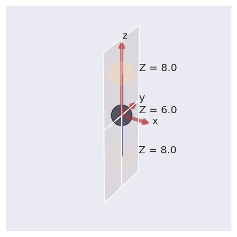

```
*** Molecular orbital list (from ePS output file)
EH = Energy (Hartrees), E = Energy (eV), NOrbGrp, OrbGrp, GrpDegen = degeneracies and corresponding orbital numbering by group in ePS, NormInt = single centre expansion convergence (should be ~1.0).
```

| props orb | Sym | EH | Occ | E | NOrbGrp | OrbGrp | GrpDegen | NormInt |
| --- | --- | --- | --- | --- | --- | --- | --- | --- |
| 1 | SU | -20.6434 | 2.0 | -561.735531 | 1.0 | 1.0 | 1.0 | 0.974763 |
| 2 | SG | -20.6433 | 2.0 | -561.732810 | 1.0 | 2.0 | 1.0 | 0.977603 |
| 3 | SG | -11.4445 | 2.0 | -311.420710 | 1.0 | 3.0 | 1.0 | 1.000000 |
| 4 | SG | -1.5454 | 2.0 | -42.052476 | 1.0 | 4.0 | 1.0 | 0.999082 |
| 5 | SU | -1.4923 | 2.0 | -40.607552 | 1.0 | 5.0 | 1.0 | 0.998756 |
| 6 | SG | -0.7978 | 2.0 | -21.709244 | 1.0 | 6.0 | 1.0 | 0.999632 |
| 7 | SU | -0.7482 | 2.0 | -20.359559 | 1.0 | 7.0 | 1.0 | 0.999765 |
| 8 | PU | -0.7273 | 2.0 | -19.790841 | 1.0 | 8.0 | 2.0 | 0.999973 |
| 9 | PU | -0.7273 | 2.0 | -19.790841 | 2.0 | 8.0 | 2.0 | 0.999973 |
| 10 | PG | -0.5465 | 2.0 | -14.871023 | 1.0 | 9.0 | 2.0 | 0.999965 |
| 11 | PG | -0.5465 | 2.0 | -14.871023 | 2.0 | 9.0 | 2.0 | 0.999965 |

```
*** Warning: some orbital convergences outside single-center expansion convergence tolerance (0.01):
[[1.         0.97476329]
 [2.         0.97760302]]
```

```python
# data.jobs

data.molSummary()
```

**NOTE: 1st IP 13.78eV [from NIST](https://webbook.nist.gov/cgi/cbook.cgi?ID=C124389&Mask=20), so should shift energies by approx 1eV here.** (i.e. orb energies in table above +1eV, hence Eke +1eV for a given photon energy.)

```python
# TODO!
# Fix labels for plots

# # Set state labels
# v = ['C','B','A','X']
# sDict = {n:v[k] for k,n in enumerate(range(9,13))}

# for key in data.data.keys():
#     data.data[key]['jobNotes']['orbKey'] = key  # Existing orb key, from filename
#     data.data[key]['jobNotes']['orbGroup'] = int(key.strip('orb')) + 1   # Corrected orb group
# #     data.data[key]['jobNotes']['orbLabel'] = f"HOMO - {12 - int(key.strip('orb')) - 1}"
#     data.data[key]['jobNotes']['orbLabel'] = sDict[data.data[key]['jobNotes']['orbGroup']]
```

## Compute AF

Note default case assumes linear pol, $z$-axis alignment.

```python
# Set ADMs to use for calc - set for specific T and downsample

# Subselection, note temperature is set by dataKey here
# temp = '10K'
admKey = dataPath.name   # For dir case
trange = [25,40]
# ADMin.subsetADMs(dataKey = temp, trange=[35,45],tStep = 5)
ADMin.subsetADMs(dataKey = admKey, trange=trange,tStep = 8)

# Plot subselection
ADMin.plot(keys='ADM')

# Set to main data structure for calcs
data.data['ADM'] = ADMin.data['ADM']
```

```
Setting subset data from `self.data['CO2_ADMs_070125']['ADM']`
Selecting 38 points
Set subset data to `self.data['ADM']['ADM']`
```

```python
# Basic routine (no grouping)
import epsproc as ep
thres = 1e-6
# data.AFBLM(AKQS = data.data['ADM']['ADM'].real, selDims = {'Type':'L'}, thres=1e-2) # OK for 41 t-points (x2 downsample), but missing some orbs and t-points in output!
# data.AFBLM(AKQS = data.data['ADM']['ADM'].real, selDims = {'Type':'L'}, thres=thres) # OK for 41 t-points (x2 downsample), still some missing regions for thres=1e-2
                                                                                       # mostly contiguous for thres = 1e-3,1e-4
data.AFBLM(AKQS = data.data['ADM']['ADM'].real, selDims = {'Type':'L'}, thres=thres)   # outputs fairly smooth for thres=1e-5

# # Save full class with Pickle
# # TODO: GENERAL DEBUG FOR ACCIDENTAL FUNCTION PASSING HERE!!!!
# import pickle
# temp = 'exp'
# outfile = f'CO2_AFBLM_{temp}_t{trange[0]}-{trange[1]}_{thres}_180225.pickle'
# with open(outfile, 'wb') as handle:
# #     data.data['ADM']['plots']['ADM']['pData'].attrs['pTypeDetails'] = []  # UGH, this breaks pickle unless removed.
#     pickle.dump(data.data, handle, protocol=pickle.HIGHEST_PROTOCOL)
#     print(f'Saved data.data with pickle, file: {outfile}')

#     # Also save to HDF5 (AFBLM only)
#     for orb in data.data.keys():
#         # Skip non-orb keys
#         # if orb.startswith('orb'):
#         if orb.startswith('co2'):
#             ep.IO.writeXarray(data.data[orb]['AFBLM'], fileName=f'CO2_AFBLM_{orb}_{temp}_t{trange[0]}-{trange[1]}_{thres}_180225.h5', engine='hdf5')
```

```python
# # Load data from previous runs...
# thres = 1e-5
# # infile = f'N2O_AFBLM_{temp}_{thres}_220323.pickle'
# # infile = 'N2O_AFBLM_10K_0.0001_220323.pickle'
# # infile = 'N2O_AFBLM_10K_1e-05_220323.pickle'
# infile = f'N2O_AFBLM_{temp}_t{trange[0]}-{trange[1]}_{thres}_120624.pickle'

# import pickle
# with open(infile, 'rb') as handle:
#     dataIn = pickle.load(handle)

# data.data = dataIn
```

## Plots

Remarks:

### Cross-sections & AF-$\beta_{L,M}$ heatmaps

NOTE: interactive plots. Roll over plots for values and tool options. For heatmaps use the "box select" tool on the histogram at the side to change the colour mapping scale.

```python
# # v2 with pkg code...
# # from epsproc.plot import hvPlotters
# # hvPlotters.setPlotDefaults(fSize = [700,300], imgSize = 600)
# data.BLMplot(backend='hv', xDim = 't', hvType='heatmap', addHist = True, addADMs = True, XS=True,
#              # selDims={'L':[2,4,6]},
#              # Etype = 'Ehv',
#              clim=(-0.5,0.5), cmap='vlag', width=1000, frame_width=860, filterXS=1e-3)
```

### AFPADs

Selected by orb, Eke and t.

```python
# data.verbose['main']=True
# data.padPlot(keys='orb8_S', dataType='AFBLM',Etype='t', squeeze=True, selDims={'Eke':[5.1],'t':data.data['orb8_S']['AFBLM'].t[slice(20,50,5)]},
#              width = 1400, height = 800, backend='pl')
```

```python
# AFPADs at selected (E,t)
# data.verbose['main']=True
# data.padPlot(keys='orb8_S', dataType='AFBLM',Etype='t', squeeze=True, selDims={'Eke':[5.1],'t':data.data['orb8_S']['AFBLM'].t[slice(20,50,2)]},
#              width = 1400, height = 1200, backend='pl')
```

```python
# Phi-summed PADs vs. t (single Eke)
# data.padPlot(dataType='AFBLM',Etype='t', squeeze=False, selDims={'Eke':[5.1]},   # selDims={'t':data.data['orb8_S']['AFBLM'].t[slice(20,50,2)]},
#              width = 1400, height = 500, reducePhi='sum', pStyle='grid', backend='hv')  #, hvClims=0.5,)  # facetDims=['Eke',None])  #, hvClims=None, hvCHist=False)   #facetDims=['Labels', 'Eke'])  #, backend='pl', reducePhi='sum')
```

```python
# Phi-summed PADs vs. t (single Eke), global cmap
# data.padPlot(dataType='AFBLM',Etype='t', squeeze=False, selDims={'Eke':[5.1]},   # selDims={'t':data.data['orb8_S']['AFBLM'].t[slice(20,50,2)]},
#              width = 1400, height = 500, reducePhi='sum', pStyle='grid', backend='hv', clim=(0,30), hvCHist=False)
```

### AF-$\beta_{L,M}$ line-outs

Results as above, line-outs per (orb,Eke) with interactive browser widget.

```python
# Line-outs
# Note this is quite slow to render
# data.BLMplot(backend='hv', hvType='line', xDim = 't', ylim=(-1,2), filterXS=1e-3,
#              addADMs = False, height=800, width=1000)

# For Ehv case can't plot all at once, so set panels per orb/job

for k in data.jobKeys:
    data.BLMplot(backend='hv', hvType='line', xDim = 't', # ylim=(-0.5,1), filterXS=1e-3,
                 # Etype = 'Ehv',
                 keys = k,
                 addADMs = False, height=300, width=1000, title = f"{k}, norm={normType}, thres={thres}")
```

```
BLMplot set data and plots to self.plots['BLMplot']
```

```
BLMplot set data and plots to self.plots['BLMplot']
```

```
BLMplot set data and plots to self.plots['BLMplot']
```

```
BLMplot set data and plots to self.plots['BLMplot']
```

```python
# Alternative composition...
# Runs, but missing Eke widget???

# data.BLMplot(backend='hv', hvType='line', xDim = 't', # ylim=(-0.5,1), filterXS=1e-3,
#              # Etype = 'Ehv',
#              renderPlot = False,
#              addADMs = False, height=400, width=1000)  #, title = f"{k}, norm={normType}, thres={thres}")

# (data.plots['BLMplot']['hv'].select(Eke=11.1).select(l=[2,4,6]).overlay('l').opts(width=1000).layout('Orb')).cols(1)
```

### AF + expt

```python
# Read from XLSX file
import pandas as pd

# Original data April 2024
# df = pd.read_excel('~/jake-home/projects-share/woodhouse_minns_collabs_2023/co2_eli_2024/exp_results_april_2024/CO2_scan_betas.xlsx').set_index('Delay')

# Data with B6 Feb 2025
df = pd.read_excel('~/jake-home/projects-share/woodhouse_minns_collabs_2023/co2_eli_2024/CO2_exp_results_Feb_2025/CO2_scan_betas.xlsx').set_index('Delay')

# Resort to state, L indexing...

newCols = pd.MultiIndex.from_product([['E','X'],[2,4,6]])  # str for HV plot

# for item df.columns.to_list():

df = df.reindex(sorted(df.columns), axis=1)
df.columns = newCols

# Plot - recall issues with Multiindex and hvplot... should be ok with HV directly?
import hvplot.pandas

dfPlot = df['X']
# dfPlot.columns = dfPlot.columns.to_flat_index()
expPlot = dfPlot.hvplot(height=300, width=1000, grid=True, title='Expt. X')
```

```python
k = 'co2_1pg_0.1-50.1eV'
data.BLMplot(backend='hv', hvType='line', xDim = 't', # ylim=(-0.5,1), filterXS=1e-3,
             # Etype = 'Ehv',
             keys = k,
             addADMs = False, height=300, width=1000, title = f"{k}, norm={normType}, thres={thres}",
             renderPlot = False)


(data.plots['BLMplot']['hv'].select(Eke=11.1).select(l=[2,4,6]).overlay('l').opts(width=1000, height=300, title='ePSproc X') + expPlot).cols(1)
```

```
BLMplot set data and plots to self.plots['BLMplot']
```

## Versions

### Code

```python
# print(data.jobInfo['ePolyScat'][0])
# print('Run: ' + jobInfo['Starting'][0].split('at')[1])
```

```python
import scooby
scooby.Report(additional=['epsproc', 'xarray', 'jupyter', 'holoviews', 'pandas'])
```

| Tue Feb 18 13:46:12 2025 EST |  |  |  |  |  |  |  |
| --- | --- | --- | --- | --- | --- | --- | --- |
| OS | Linux | CPU(s) | 64 | Machine | x86_64 | Architecture | 64bit |
| RAM | 62.8 GiB | Environment | Jupyter | File system | btrfs |  |  |
| Python 3.10.11 \| packaged by conda-forge \| (main, May 10 2023, 18:58:44) [GCC 11.3.0] |  |  |  |  |  |  |  |
| epsproc | 1.3.2-dev | xarray | 2022.3.0 | jupyter | Version unknown | holoviews | 1.16.2 |
| pandas | 1.5.3 | numpy | 1.23.5 | scipy | 1.10.1 | IPython | 8.13.2 |
| matplotlib | 3.5.3 | scooby | 0.7.2 |  |  |  |  |

```python
# Check current Git commit for local ePSproc version
import epsproc as ep
!git -C {Path(ep.__file__).parent} branch
!git -C {Path(ep.__file__).parent} log --format="%H" -n 1
```

```
* 3d-AFPAD-dev
  dev
  master
56c01f0a1f3ba90c1409a32a276c241e04165638
```

```python
# Check current remote commits
!git ls-remote --heads https://github.com/phockett/ePSproc
```

```
56c01f0a1f3ba90c1409a32a276c241e04165638	refs/heads/3d-AFPAD-dev
ff437df39999292cefaa659749067b063db68ce8	refs/heads/dependabot/pip/notes/envs/envs-versioned/ipython-8.10.0
840c9a0fdbd9b1a66f5a0275ea7fa6db2193c8a6	refs/heads/dependabot/pip/notes/envs/envs-versioned/jinja2-3.1.5
0e5e04353d0fbf2da5b5de120a1e87d03de865dd	refs/heads/dependabot/pip/notes/envs/envs-versioned/tornado-6.4.2
a00ba1c9e762c85bdae2de68d4b93214ddee9063	refs/heads/dependabot/pip/notes/envs/envs-versioned/wheel-0.38.1
7e4270370d66df44c334675ac487c87d702408da	refs/heads/dev
1c0b8fd409648f07c85f4f20628b5ea7627e0c4e	refs/heads/master
69cd89ce5bc0ad6d465a4bd8df6fba15d3fd1aee	refs/heads/numba-tests
ea30878c842f09d525fbf39fa269fa2302a13b57	refs/heads/revert-9-master
baf0be0c962e8ab3c3df57c8f70f0e939f99cbd7	refs/heads/testDev
```

```python
import epsproc as ep
ep.__file__
```

```
'/home/jovyan/code-share/github-share/ePSproc/epsproc/__init__.py'
```